# KEY 09 Regression

## GRADED ANOVA table - survival DOES depend…

1.13 Add a comment to your script interpreting the ANOVA table for our linear regression analysis. Which of the two hypotheses stated above does this table refer to? Do we reject or fail to reject that null hypotheses?

```r
# The ANOVA table is only related to our null hypotheses regarding the regression coefficient (beta_1). There is no information in the ANOVA table related to our intercept coefficient (beta_0)

# Based on our data, we reject the null hypothesis for the beta-1 coefficient and conclude that trout survival does depend on copper concentration (F_1, 23 = 696.12, p < 0.001)
```

1.14 Print out the `summary()` of the linear model object you created.

```r
summary(trout_lm)
```

```
Call:
lm(formula = trout ~ cu_ppb, data = trout)

Residuals:
    Min      1Q  Median      3Q     Max
-8.2306 -3.2469 -0.7865  3.5845  8.6644

Coefficients:
            Estimate Std. Error t value Pr(>|t|)
(Intercept)  97.3699     1.7402   55.95   <2e-16 ***
cu_ppb       -7.9850     0.3026  -26.38   <2e-16 ***
---
Signif. codes:  0 '***' 0.001 '**' 0.01 '*' 0.05 '.' 0.1 ' ' 1

Residual standard error: 4.552 on 23 degrees of freedom
Multiple R-squared:  0.968, Adjusted R-squared:  0.9666
F-statistic: 696.1 on 1 and 23 DF,  p-value: < 2.2e-16
```

1.15 Add a comment to your script describing what each coefficient means.

```r
# Intercept: This is the estimated number of trout when x (copper concentration) = 0

# cu_ppb: this coefficient is the estimated change in the number of surviving trout with every 1-unit increase in our x-variable (copper concentration).
```

## GRADED R2 = 0.9666

1.16 Add a comment which has the adjusted R-squared value from our model as well as an interpretation for what it means.

```r
# adj R^2 = 0.9666
# This means that the model explains 96.66% of the variation in the response variable.
```

1.17 Add a comment to your script writing out the full equation for our linear model.

```r
# trout = 97.37 - 7.99 * cu_ppb
```

1.18 Make a scatter plot of the data which includes a line of best fit on the plot.

- hint: you will need to add a `geom_smooth(method = "lm")` argument to your ggplot code above.

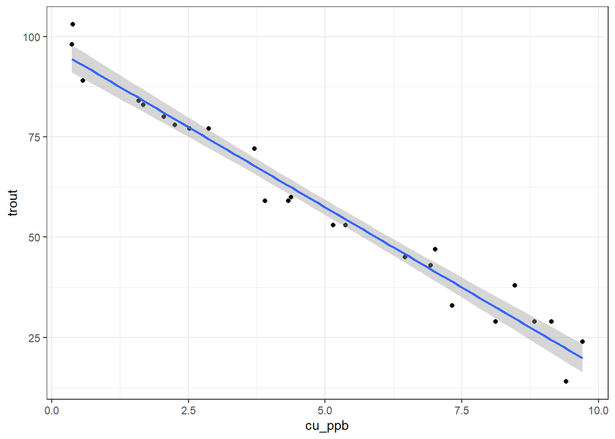

```r
ggplot(trout,
       aes(y = trout,
           x = cu_ppb)) +
  geom_point() +
  geom_smooth(method = "lm") +
  theme_bw()
```

1.19 Use the coefficient estimates from the `lm()` model to estimate the number of surviving trout when copper concentration is 5 ppb.

```r
97.37 - 7.99 * 5
```

```
[1] 57.42
```

1.20 Use the `predict()` function to estimate the number of surviving trout when the copper concentration is 0.9 ppb.

```r
predict(trout_lm, newdata = list(cu_ppb = 0.9))
```

```
       1
90.18339
```

1.21 Estimate the copper concentration for an experiment which has 35 trout surviving at the conclusion of the experiment.

- Hint: You will need to rearrange your linear model equation to have `cu_ppb` on its own on the left side of the equation.

```r
# original equation: trout = 97.37 - 7.99 * cu_ppb
# rearranged equation: cu_ppb = (trout - 97.37) / -7.99

(35 - 97.37) / -7.99
```

```
[1] 7.806008
```

## GRADED prediction plot

1.22 Use the `predict()` function to estimate the 95% *prediction* interval for the full range of copper concentrations. Once you have your prediction, make a `ggplot()` which shows the:

- Raw data
- The line of best fit (with SE)
- The prediction interval
- **Hint**
  - Make a vector covering the full range of coppoer concentrations
  - Make a new data frame called `cu_prediction` using the `predict()` function with your linear model and your vector as the newdata argument

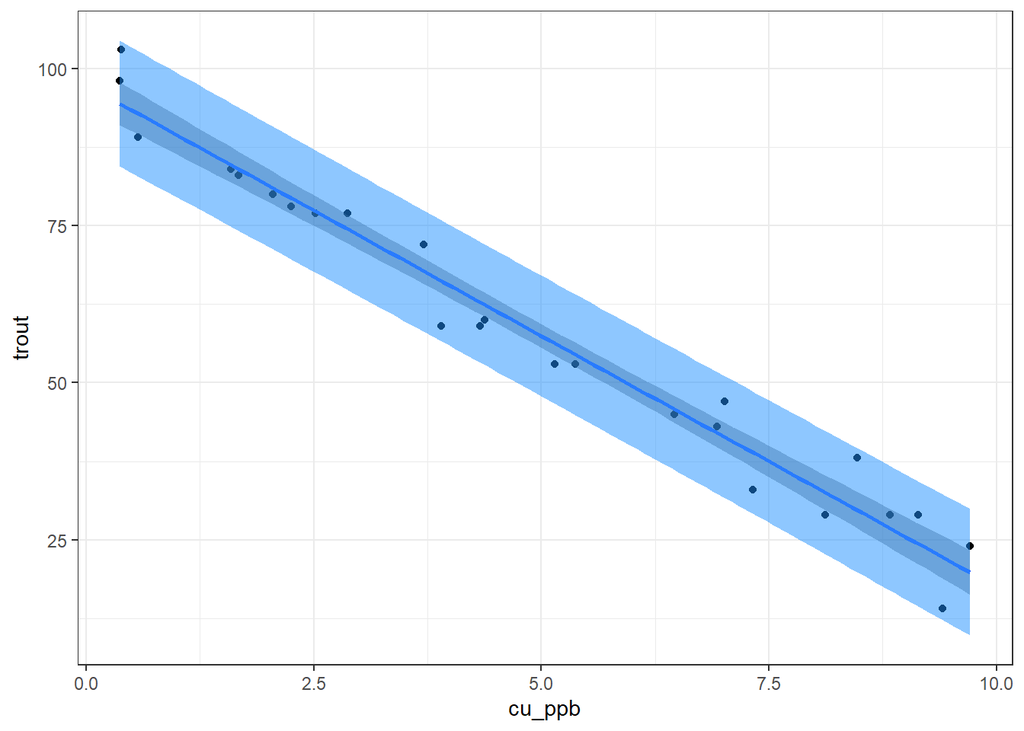

```r
cu_v <- seq(min(trout$cu_ppb), max(trout$cu_ppb), length.out = 100)

cu_prediction <- predict(trout_lm, newdata = list(cu_ppb = cu_v), interval = "predict")

pred_plot_df <- data.frame(cu_ppb = cu_v,
                       cu_prediction) |>
  rename(trout = fit)

ggplot(trout,
       aes(x = cu_ppb,
           y = trout)) +
  geom_point() +
  geom_smooth(method = "lm",
              fill = "grey30") +
  geom_ribbon(data = pred_plot_df,
              aes(ymin = lwr,
                  ymax = upr),
              fill = "dodgerblue",
              alpha = 0.5) +
  theme_bw()
```

## Problem 2: `island_plants`

### Data background

The theory of island biogeography predicts that the number of species will increase with island area. This data set is from an observational study of the number of plants occurring on islands of different sizes.

### Problem 2 questions

2.1 You should always get to know your data by looking at `names()`, `head()`.

```r
names(island)
```

```
[1] "Island"   "Area"     "Nspecies"
```

```r
head(island)
```

```
# A tibble: 6 × 3
  Island          Area Nspecies
  <chr>          <dbl>    <dbl>
1 Albemarle     5825.       325
2 Charles        166.       319
3 Chatham        505.       306
4 James          526.       224
5 Indefatigable 1008.       193
6 Abingdon        51.8      119
```

2.2 Produce a scatter plot of the data with `Nspecies` as the response variable and `Area` as the predictor variable.

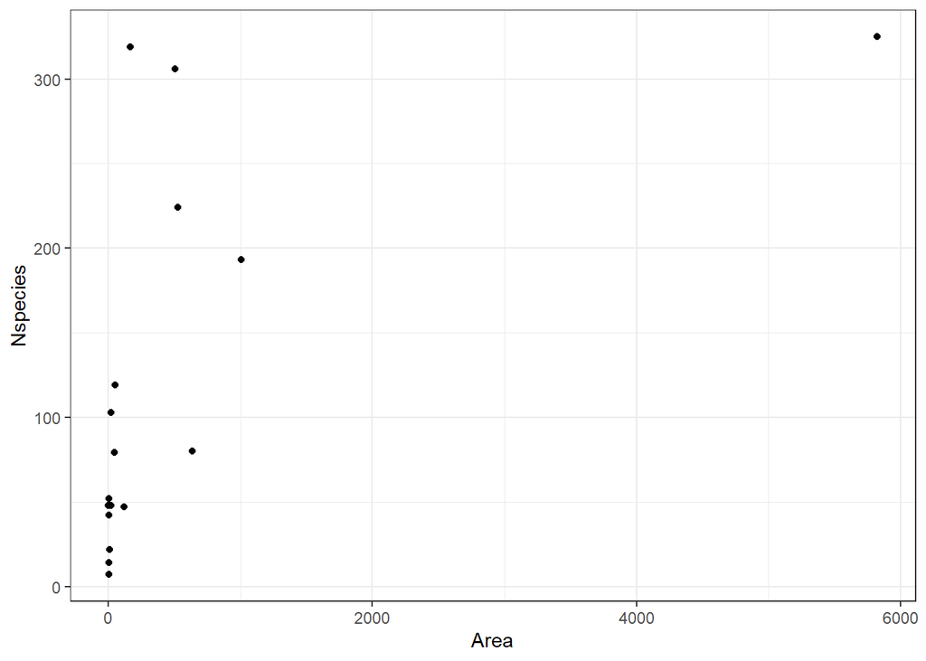

```r
ggplot(island,
       aes(y = Nspecies,
           x = Area)) +
  geom_point() +
  theme_bw()
```

2.3 Add a comment to your script interpreting this scatter plot. Does it appear that there is a linear relationship between the number of species and island area?

```r
# this looks terrible. It looks like there is nearly a vertical increase in species with island area, and there is one observation which is way far away from the rest of the observations.
```

## GRADED LOG plot

2.4 Make another scatter plot but this time log-transform the `Nspecies` and the `Area` variables.

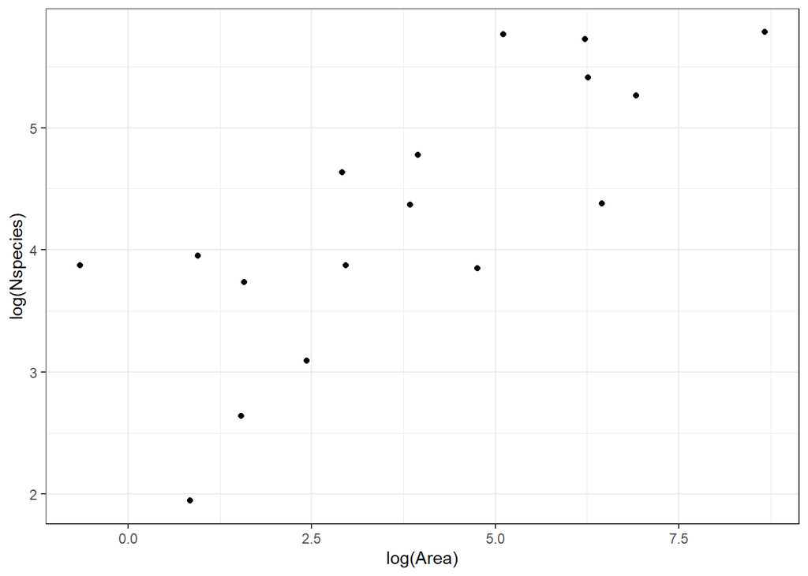

```r
ggplot(island,
       aes(y = log(Nspecies),
           x = log(Area))) +
  geom_point() +
  theme_bw()
```

2.5 Add a comment to your script interpreting this scatter plot. Does it appear that there is a linear relationship between the log-transformed number of species and island area?

```r
# this looks much better, and it appears that there is a linear relationship.
```

## We will continue this analysis using the log transformed data.

**A Brief note**

The transformation of data is a very common thing to do in an analysis. Technically speaking, our assumptions of normality, equal variance, etc. also apply to data which has been transformed. In other words, if our assumptions are met *after* transformation, this constitutes a legitimate statistical analysis. You will often see language in publications that say “we transformed the variable(s) to meet the assumptions of normality” or similar.

2.6 Perform a linear regression using the `lm()` function using the log variables and save this model in a new data object.

```r
island_lm <- lm(log(Nspecies) ~ log(Area), data = island)
```

2.7 Make a fitted vs. residual plot to check our assumption of equal variance in the residuals.

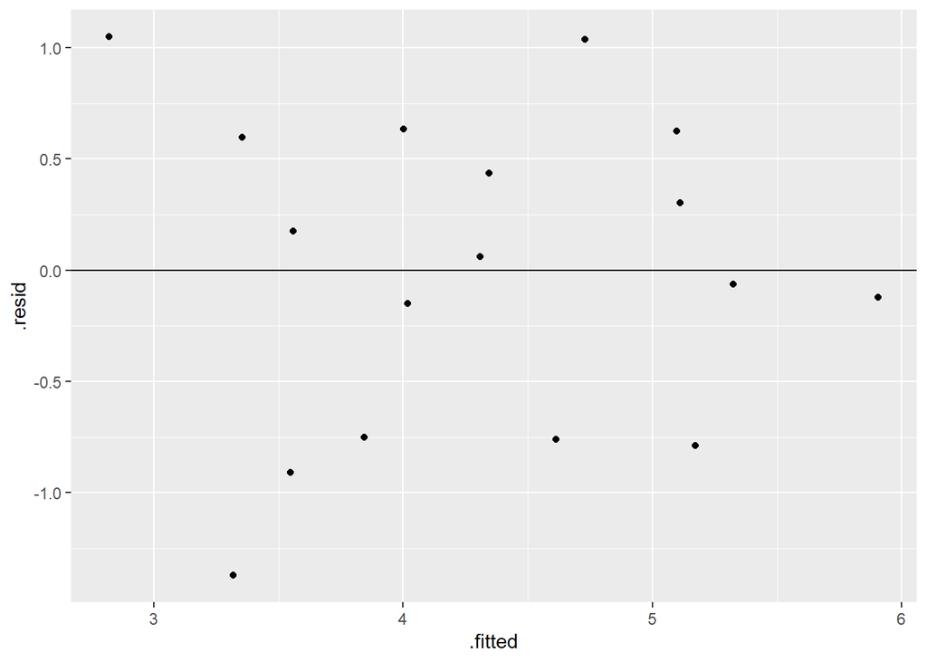

```r
ggplot(island_lm,
       aes(x = .fitted,
           y = .resid)) +
  geom_point() +
  geom_hline(yintercept = 0)
```

2.8 Add a comment to your script interpreting the fitted vs. residual plot.

```r
# the magnitude of variation looks similar above and below the line, and there is no obvious pattern to the data points.
```

2.9 Print out an ANOVA table of the `lm` object and interpret it here.

```r
anova(island_lm)
```

```
Analysis of Variance Table

Response: log(Nspecies)
          Df  Sum Sq Mean Sq F value    Pr(>F)
log(Area)  1 11.4955 11.4955  21.118 0.0003501 ***
Residuals 15  8.1652  0.5443
---
Signif. codes:  0 '***' 0.001 '**' 0.01 '*' 0.05 '.' 0.1 ' ' 1
```

```r
# the log_area variable is significant (DF_1_15 = 21.118, p < 0.001). This means that the response variable does change with island area.
```

2.10 Print out the `summary()` of your lm object here.

```r
summary(island_lm)
```

```
Call:
lm(formula = log(Nspecies) ~ log(Area), data = island)

Residuals:
     Min       1Q   Median       3Q      Max
-1.37282 -0.75233  0.06034  0.59768  1.04971

Coefficients:
            Estimate Std. Error t value Pr(>|t|)
(Intercept)  3.03895    0.32728   9.286 1.31e-07 ***
log(Area)    0.33059    0.07194   4.595  0.00035 ***
---
Signif. codes:  0 '***' 0.001 '**' 0.01 '*' 0.05 '.' 0.1 ' ' 1

Residual standard error: 0.7378 on 15 degrees of freedom
Multiple R-squared:  0.5847,    Adjusted R-squared:  0.557
F-statistic: 21.12 on 1 and 15 DF,  p-value: 0.0003501
```

## GRADED lm summary interp

2.11 For each coefficient, write out the estimate and standard error and interpret the results. Be sure to list all appropriate statistics, and relate it back to the null and alternative hypotheses for each.

```r
# Intercept
# the mean estimate and SE for the intercept coefficient is 3.04 (0.33). We reject the null hypothesis for the intercept, and conclude that it is not equal to 0 (t = 9.286, p < 0.001).

# beta_1, log_area
# # the mean estimate and SE for the regression coefficient is 0.33 (0.07). We reject the null hypothesis for the intercept, and conclude that it is not equal to 0 (t = 4.595, p < 0.001).
```

2.12 what is the adjusted R-squared for this model, and what does it mean?

```r
# The adjusted R-squared is 0.557 which means that ~56% of the variation in the response variable is explained by this model.
```

## GRADED island equation

2.13 Write out the full equation for this linear model. Be sure to put “log” in the appropriate places for these variables.

```r
# log_nspp = 3.04 + 0.33 * log_area
```

2.14 Make another scatter plot of the transformed data and include a line of best fit.

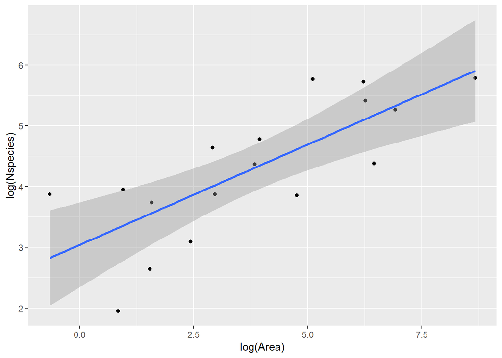

```r
ggplot(island,
       aes(y = log(Nspecies),
           x = log(Area))) +
  geom_point() +
  geom_smooth(method = "lm")
```